# MSc_CW1_13170192_D_Jaganjac.rmd.doc

# 1. Statistical Learning Methods

1. An inflexible method would work better if the number of predictors p was extremely large, and the number of observations n was small. If we were to use a flexible method, we would risk overfitting the data, which would cause the model to describe the random error instead of the underlying relationship of the data. Therefore, an inflexible method is better as this would minimise this risk.
2. If the sample size of n is extremely large, and the number of predictors p is small, it is better to use a flexible statistical learning method. By using a flexible method, the model would accurately fit a wider range of possible shapes of f. As the data set includes a very large number of observations n, it is likely to obtain an accurate estimate of f. Therefore, the use of a flexible method would be better.
3. If the relationship between the predictors p and the response is highly non-linear then it is better to use a non-linear model. As the data is highly non-linear, a flexible method would more accurately fit this data and provide a more accurate result.
4. If the standard deviation of the error terms is extremely high, then it is better to use an inflexible method to fit this data. As the variance of the errors in the data is extremely high, we would risk overfitting the data if we used a flexible statistical learning method. For this reason, it is better to use an inflexible method to minimise the amount of noise described by the high variance of the error terms.

# 2. Bayes’ Rule

Based on the given data-set of 20 samples, we can calculate:

P(Play Golf = yes) = 10/20 = 0.5

P(Play Golf = no) = 10/20 = 0.5

P(Temperature = hot) = 12/20 = 0.6

P(Temperature = cool) = 8/20 = 0.4

P(Temperature = hot | Play Golf = yes) = 5/10 = 0.5

P(Temperature = cool | Play Golf = yes) = 5/10 = 0.5

P(Temperature = hot | Play Golf = no) = 7/10 = 0.7

P(Temperature = cool | Play Golf = no) = 3/10 = 0.3

According to Bayes’ Rule, it can be calculated that:

P(Play Golf = yes | Temperature = hot) = (0.5 * 0.5) / 0.6 = 0.416

P(Play Golf = no | Temperature = hot) = (0.7 * 0.5) / 0.6 = 0.583

P(Play Golf = yes | Temperature = cool) = (0.5 * 0.5) / 0.4 = 0.625

P(Play Golf = no | Temperature = cool) = (0.3 * 0.5) / 0.4 = 0.375

# 3. Descriptive Analytics

```r
library(ISLR)
data(Auto)
View(Auto)
```

1. The quantitative predictors are mpg, cylinders, displacement, horsepower,weight, acceleration, year and origin. The only qualitative predictor is name.

```r
quant_Auto <- subset(Auto, select = -c(name))
View(quant_Auto)
```

```r
sapply(Auto[,-9], range)
```

```
##       mpg cylinders displacement horsepower weight acceleration year origin
## [1,]  9.0         3           68         46   1613          8.0   70      1
## [2,] 46.6         8          455        230   5140         24.8   82      3
```

```r
sapply(Auto[,-9], median)
```

```
##          mpg    cylinders displacement   horsepower       weight acceleration
##        22.75         4.00       151.00        93.50      2803.50        15.50
##         year       origin
##        76.00         1.00
```

```r
sapply(Auto[,-9], var)
```

```
##          mpg    cylinders displacement   horsepower       weight acceleration
## 6.091814e+01 2.909696e+00 1.095037e+04 1.481569e+03 7.214847e+05 7.611331e+00
##         year       origin
## 1.356991e+01 6.488595e-01
```

```r
reduced_Auto <- Auto[-c(11:79), ]
View(reduced_Auto)
sapply(reduced_Auto[,-9], range)
```

```
##       mpg cylinders displacement horsepower weight acceleration year origin
## [1,] 11.0         3           68         46   1649          8.5   70      1
## [2,] 46.6         8          455        230   4997         24.8   82      3
```

```r
sapply(reduced_Auto[,-9], median)
```

```
##          mpg    cylinders displacement   horsepower       weight acceleration
##         23.9          4.0        144.0         90.0       2789.0         15.5
##         year       origin
##         77.0          1.0
```

```r
sapply(reduced_Auto[,-9], var)
```

```
##          mpg    cylinders displacement   horsepower       weight acceleration
## 6.135039e+01 2.748938e+00 1.003229e+04 1.291977e+03 6.574970e+05 7.296234e+00
##         year       origin
## 1.004873e+01 6.803261e-01
```

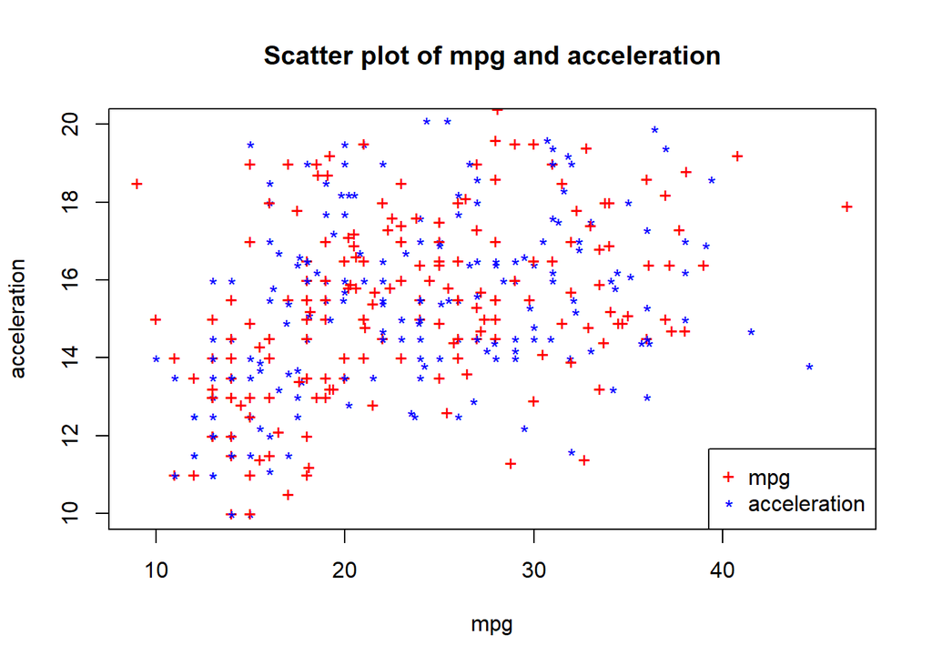

```r
plot(Auto$mpg,Auto$acceleration, col=c("red","blue"), pch = c("+", "*"),
     main = "Scatter plot of mpg and acceleration",
     xlab = "mpg", ylab = "acceleration", ylim = c(10,20))

legend("bottomright", pch =c("+", "*"),
       col = c("red", "blue"),
       legend = c("mpg", "acceleration"))
```

The scatter plot of mpg and acceleration seems to have weak positive correlation. As the mpg increases, the acceleration also tends to increase.

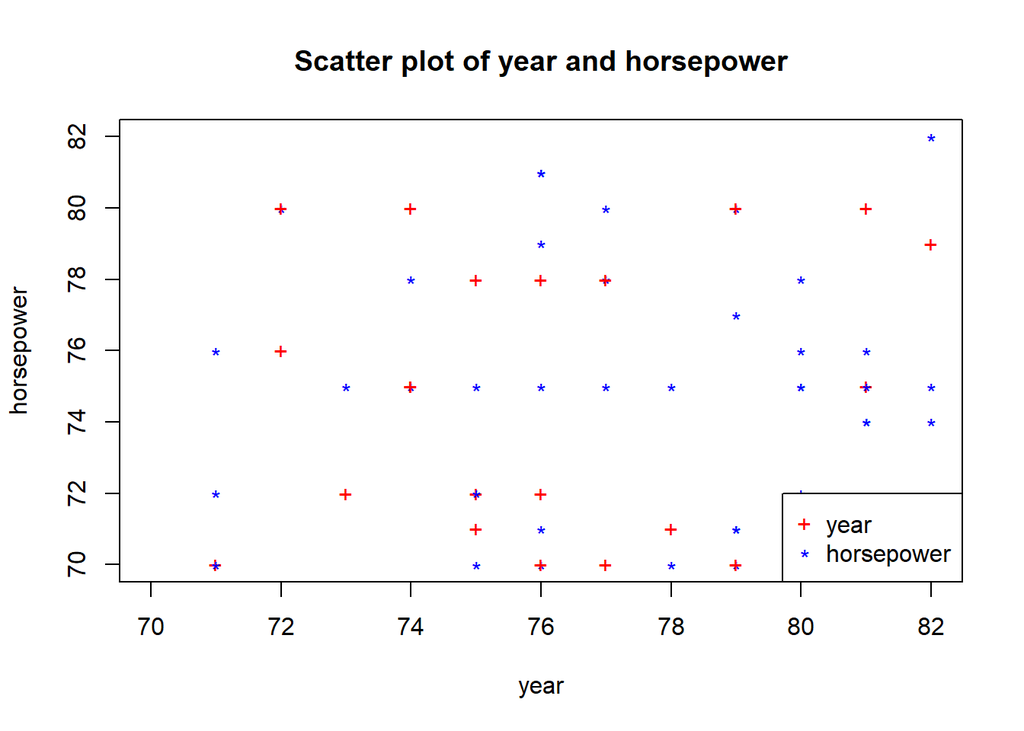

```r
plot(Auto$year, Auto$horsepower, col=c("red","blue"), pch = c("+", "*"),
     main = "Scatter plot of year and horsepower", xlab = "year", ylab = "horsepower", ylim = c(70,82))

legend("bottomright", pch =c("+", "*"),
       col = c("red", "blue"),
       legend = c("year","horsepower"))
```

It is difficult to see visually whether there is any correlation at all for this scatterplot, and it does seem like there is no correlation at all. However, by comparing the smallest and largest years in detail, it can be observed that as year increases, there is also an increase in horsepower.

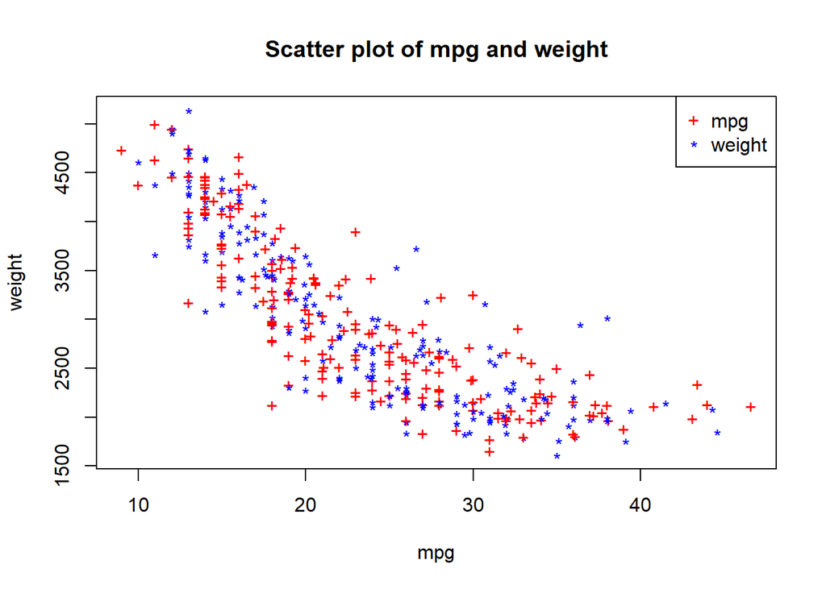

```r
plot(Auto$mpg,Auto$weight, col=c("red","blue"), pch = c("+", "*"),
     main = "Scatter plot of mpg and weight",
     xlab = "mpg", ylab = "weight")

legend("topright", pch =c("+", "*"),
       col = c("red", "blue"),
       legend = c("mpg", "weight"))
```

There is a medium to strong negative correlation here between mpg and weight.It seems thats as mpg increases, the weight decreases.

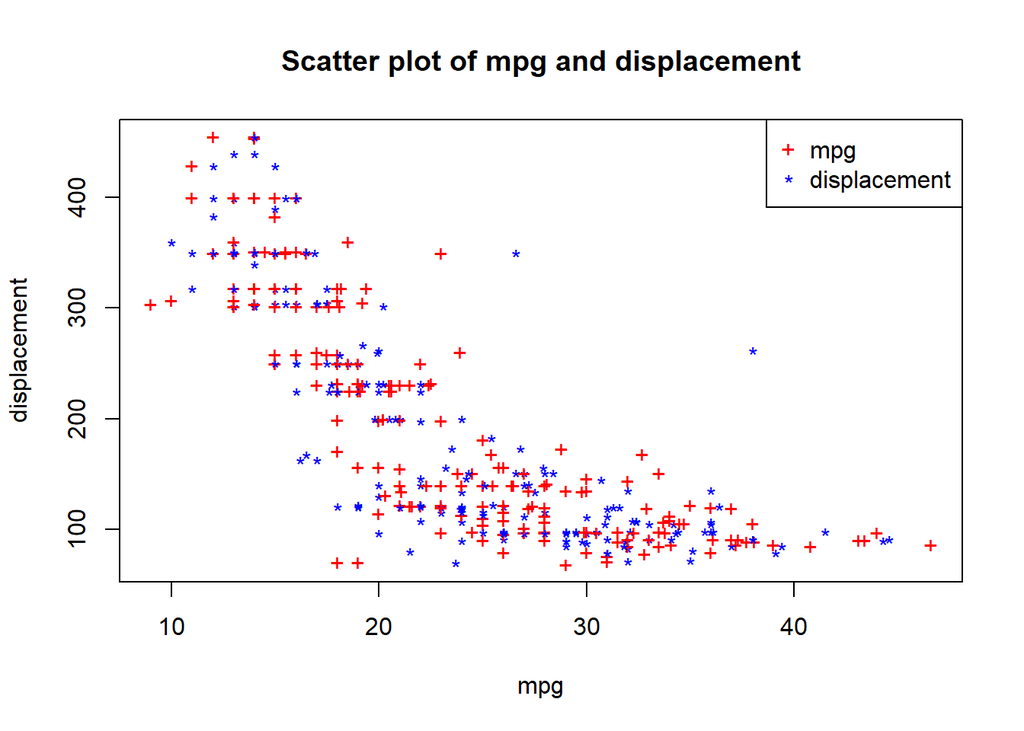

```r
plot(Auto$mpg,Auto$displacement, col=c("red","blue"), pch = c("+", "*"),
     main = "Scatter plot of mpg and displacement",
     xlab = "mpg", ylab = "displacement")

legend("topright", pch =c("+", "*"),
       col = c("red", "blue"),
       legend = c("mpg", "displacement"))
```

There is a medium to strong negative correlation for this graph. As mpg increases, displacement decreases.

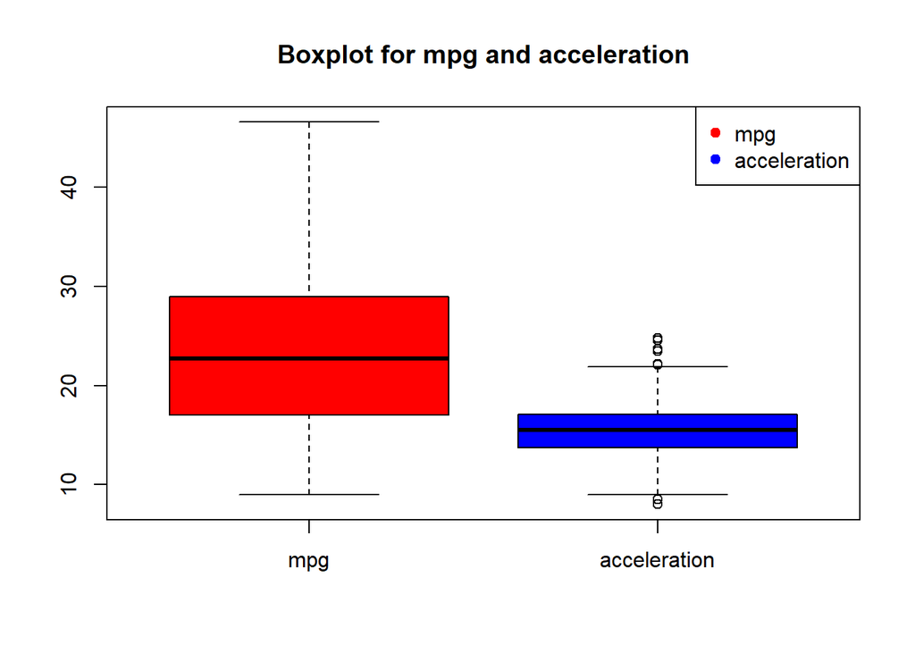

```r
boxplot(Auto$mpg,Auto$acceleration,
        col = c("red","blue"),
        names = c("mpg", "acceleration"),
        main = "Boxplot for mpg and acceleration")

legend("topright", pch = c(19),
       col = c("red", "blue"),
       legend = c("mpg", "acceleration"))
```

This boxplot opposes what the scatter-graph showed for mpg and acceleration, as it implies that mpg and acceleration are not related.

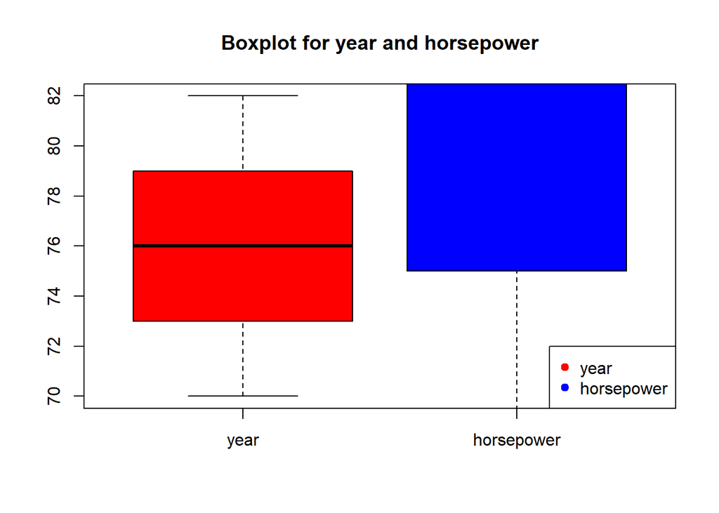

```r
boxplot(Auto$year,Auto$horsepower,
        col = c("red","blue"),
        names = c("year", "horsepower"), ylim = c(70,82),
        main = "Boxplot for year and horsepower")

legend("bottomright", pch = c(19),
       col = c("red", "blue"),
       legend = c("year", "horsepower"))
```

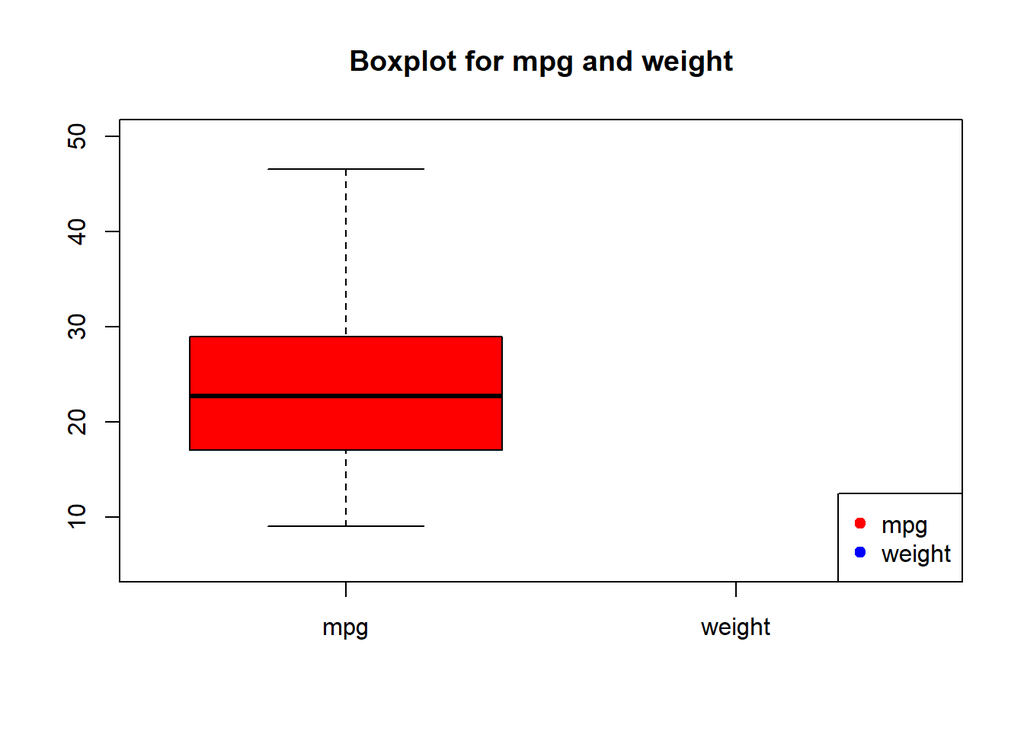

```r
boxplot(Auto$mpg,Auto$weight, ylim = c(5,50),
        col = c("red","blue"),
        names = c("mpg", "weight"),
        main = "Boxplot for mpg and weight")

legend("bottomright", pch = c(19),
       col = c("red", "blue"),
       legend = c("mpg", "weight"))
```

Although the scatter-graph for mpg and weight indcates medium to strong negative correlation, the scales for the boxplot for mpg and weight do not align and therefore no conclusion can be drawn.

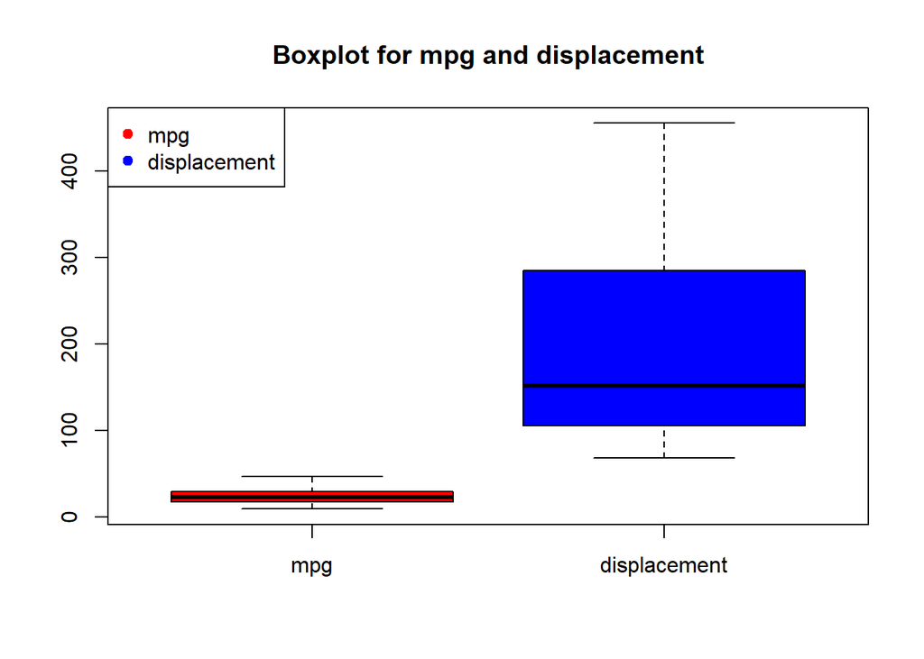

```r
boxplot(Auto$mpg,Auto$displacement,
        col = c("red","blue"),
        names = c("mpg", "displacement"),
        main = "Boxplot for mpg and displacement")

legend("topleft", pch = c(19),
       col = c("red", "blue"),
       legend = c("mpg", "displacement"))
```

Despite the scatter-graph for mpg and displacement showing medium to strong negative correlation, the scales for this boxplot do not align and therefore no conclusion can be drawn. In fact, the conclusion could be drawn that mpg and displacement are not related at all, from this boxplot.

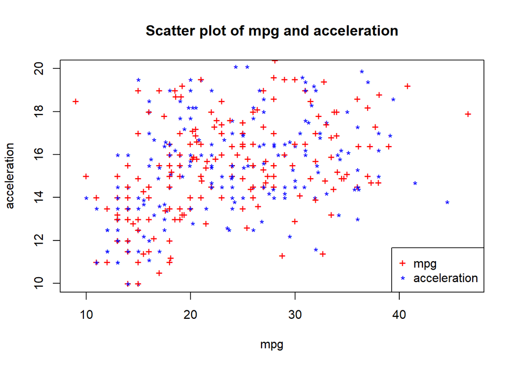

```r
plot(Auto$mpg,Auto$acceleration, col=c("red","blue"), pch = c("+", "*"),
     main = "Scatter plot of mpg and acceleration",
     xlab = "mpg", ylab = "acceleration", ylim = c(10,20))

legend("bottomright", pch =c("+", "*"),
       col = c("red", "blue"),
       legend = c("mpg", "acceleration"))
```

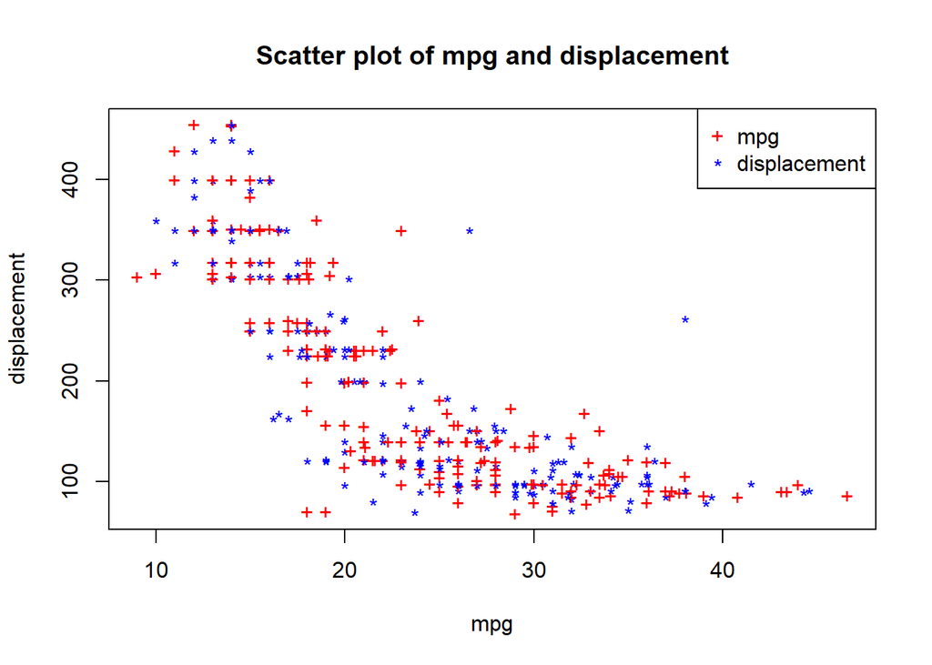

```r
plot(Auto$mpg,Auto$displacement, col=c("red","blue"), pch = c("+", "*"),
     main = "Scatter plot of mpg and displacement",
     xlab = "mpg", ylab = "displacement")

legend("topright", pch =c("+", "*"),
       col = c("red", "blue"),
       legend = c("mpg", "displacement"))
```

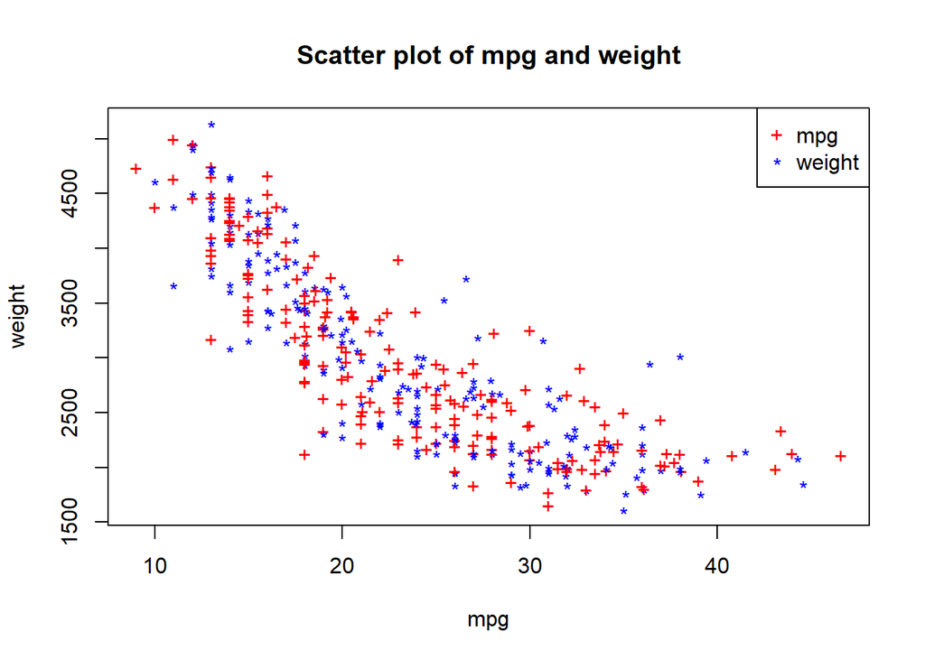

```r
plot(Auto$mpg,Auto$weight, col=c("red","blue"), pch = c("+", "*"),
     main = "Scatter plot of mpg and weight",
     xlab = "mpg", ylab = "weight")

legend("topright", pch =c("+", "*"),
       col = c("red", "blue"),
       legend = c("mpg", "weight"))
```

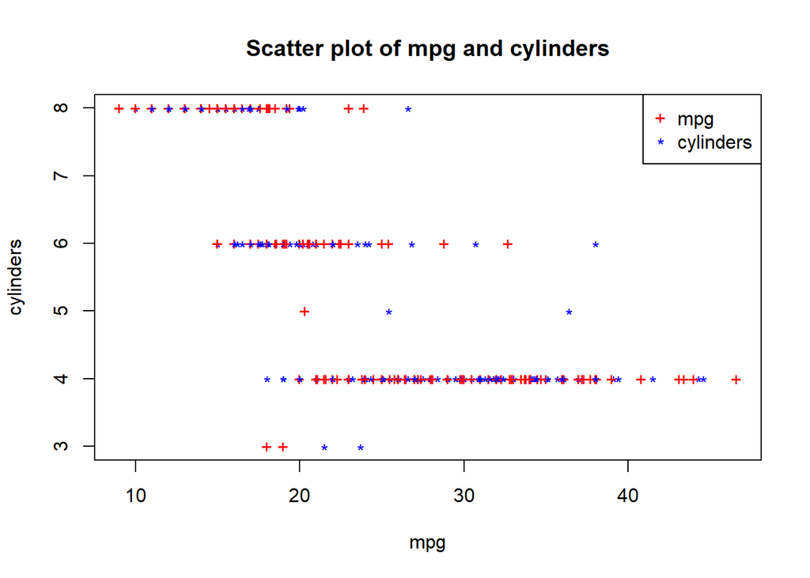

```r
plot(Auto$mpg,Auto$cylinders, col=c("red","blue"), pch = c("+", "*"),
     main = "Scatter plot of mpg and cylinders",
     xlab = "mpg", ylab = "cylinders")

legend("topright", pch =c("+", "*"),
       col = c("red", "blue"),
       legend = c("mpg", "cylinders"))
```

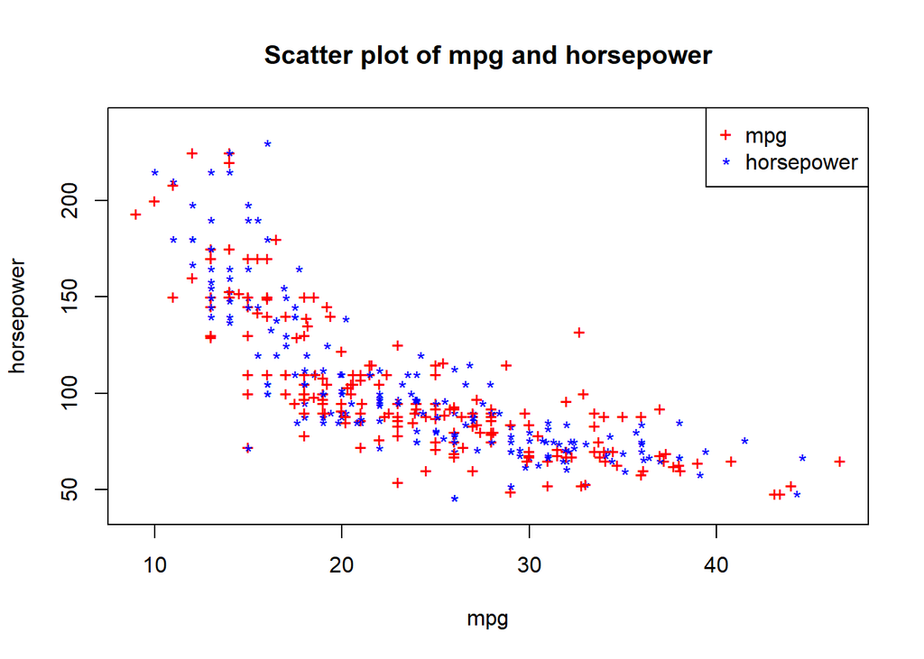

```r
plot(Auto$mpg,Auto$horsepower, col=c("red","blue"), pch = c("+", "*"),
     main = "Scatter plot of mpg and horsepower",
     xlab = "mpg", ylab = "horsepower", ylim = c(40,240))

legend("topright", pch =c("+", "*"),
       col = c("red", "blue"),
       legend = c("mpg", "horsepower"))
```

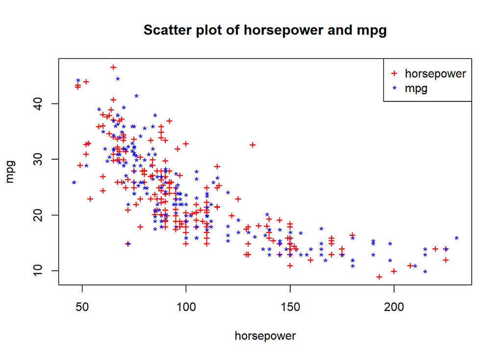

```r
plot(Auto$horsepower, Auto$mpg, col=c("red","blue"), pch = c("+", "*"),
     main = "Scatter plot of horsepower and mpg",
     xlab = "horsepower", ylab = "mpg")

legend("topright", pch =c("+", "*"),
       col = c("red", "blue"),
       legend = c("horsepower", "mpg"))
```

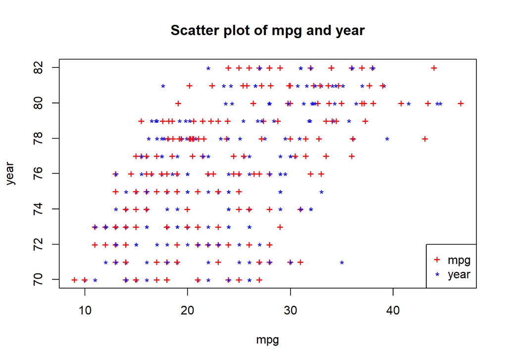

```r
plot(Auto$mpg,Auto$year, col=c("red","blue"), pch = c("+", "*"),
     main = "Scatter plot of mpg and year",
     xlab = "mpg", ylab = "year")

legend("bottomright", pch =c("+", "*"),
       col = c("red", "blue"),
       legend = c("mpg", "year"))
```

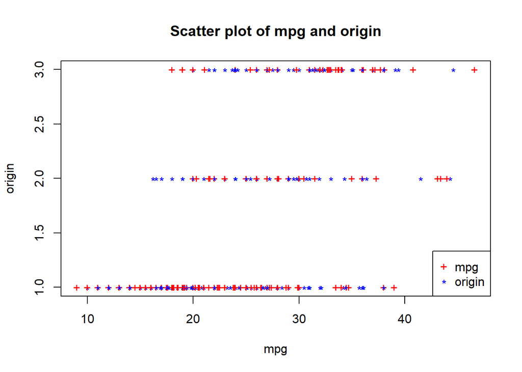

```r
plot(Auto$mpg,Auto$origin, col=c("red","blue"), pch = c("+", "*"),
     main = "Scatter plot of mpg and origin",
     xlab = "mpg", ylab = "origin")

legend("bottomright", pch =c("+", "*"),
       col = c("red", "blue"),
       legend = c("mpg", "origin"))
```

Based on the scatter-plots above, the most useful variables for predicting gas mileage (mpg) due to a potential relationship between the variable and mpg are: acceleration, displacement, weight, horsepower and year. The variables which are not so useful and have no significant relationship are: cylinders and origin.

From the scatter-graphs against mpg, we can see that:

As mpg increases acceleration increases; As mpg increases displacement decreases; As mpg increases weight decreases; As mpg increases horsepower decreases.

There is also a weak relationship between mpg and year such that as mpg increases, year also tends to increase.

For mpg and cylinders, it is difficult to gain any conclusions from the scatter-plot. For mpg and origin, there is an indication of origin increasing as year increases, however I would not deem this to be a significant or very useful observation compared to others. Therefore, predicting mpg based on the relationship mpg has with cylinders or origin is not as useful as the other above mentioned variables.

#4. Linear Regression

```r
horsempg <- data.frame(Auto$mpg, Auto$horsepower)
lm.fit <- lm(mpg~horsepower, data = Auto)
summary(lm.fit)
```

```
##
## Call:
## lm(formula = mpg ~ horsepower, data = Auto)
##
## Residuals:
##      Min       1Q   Median       3Q      Max
## -13.5710  -3.2592  -0.3435   2.7630  16.9240
##
## Coefficients:
##              Estimate Std. Error t value Pr(>|t|)
## (Intercept) 39.935861   0.717499   55.66   <2e-16 ***
## horsepower  -0.157845   0.006446  -24.49   <2e-16 ***
## ---
## Signif. codes:  0 '***' 0.001 '**' 0.01 '*' 0.05 '.' 0.1 ' ' 1
##
## Residual standard error: 4.906 on 390 degrees of freedom
## Multiple R-squared:  0.6059, Adjusted R-squared:  0.6049
## F-statistic: 599.7 on 1 and 390 DF,  p-value: < 2.2e-16
```

1. The results of the linear regression model describe a large t-value and a very small p-value. Therefore we are able to reject the null hypothesis and declare a relationship between mpg and horsepower.
2. The relationship between the predictor and the response is very significant as it is close to 0. The significance code indicates this as it shows thre stars ’***’ indicating high significance.
3. The relationship between the predictor and the response is negative, as the B1 coefficient is negative, indicating that the slope of the regression line is negative.

```r
predict(lm.fit, newdata = data.frame(horsepower=89))
```

```
##        1
## 25.88768
```

```r
predict(lm.fit,newdata=data.frame(horsepower=89), interval = "confidence")
```

```
##        fit      lwr      upr
## 1 25.88768 25.36257 26.41279
```

```r
predict(lm.fit,newdata=data.frame(horsepower=89), interval = "prediction")
```

```
##        fit      lwr    upr
## 1 25.88768 16.22836 35.547
```

The predicted mpg associated with a horsepower of 89 is 25.88768.

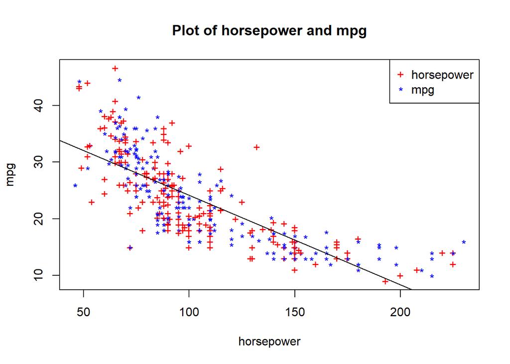

```r
plot(Auto$horsepower, Auto$mpg, col=c("red","blue"), pch = c("+", "*"), xlab = "horsepower", ylab = "mpg",
     main = "Plot of horsepower and mpg")

legend("topright", pch =c("+", "*"),
       col = c("red", "blue"),
       legend = c("horsepower", "mpg"))

abline(lm.fit)
```

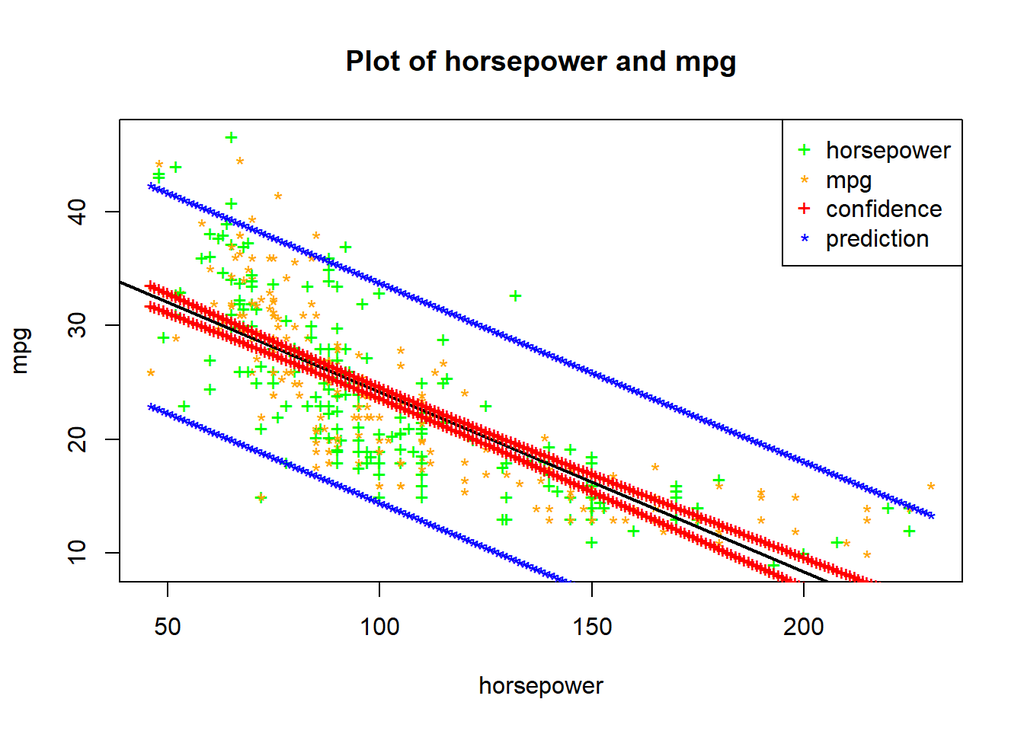

```r
plot(Auto$horsepower, Auto$mpg, col = c("green", "orange"), pch = c("+", "*"), xlab = "horsepower", ylab = "mpg",
     main = "Plot of horsepower and mpg")

abline(lm.fit, lwd = 2)

powermpg = data.frame(horsepower = seq(46, 230))

p_conf <- predict(lm.fit, interval = "confidence", newdata = powermpg)
p_pred <- predict(lm.fit, interval = "prediction", newdata = powermpg)

lines(powermpg$horsepower, p_conf[,"lwr"], col="red", type="b", pch="+")
lines(powermpg$horsepower, p_conf[,"upr"], col="red", type="b", pch="+")
lines(powermpg$horsepower, p_pred[,"upr"], col="blue", type="b", pch="*")
lines(powermpg$horsepower, p_pred[,"lwr"], col="blue", type="b", pch="*")

legend("topright",
       pch=c("+", "*"),
       col=c("green","orange","red","blue"),
       legend = c("horsepower","mpg", "confidence","prediction"))
```

#5. Logistic Regression

```r
Training_set = read.table("C:/Dina/Training_set.txt",header=T, sep = ',')

Testing_set = read.table("C:/Dina/Testing_set.txt",header=T, sep = ',')

head(Training_set)
```

```
##   Temperature Humidity Light    CO2 HumidityRatio Occupancy
## 1       23.18  27.2720 426.0 721.25   0.004792988         1
## 2       23.15  27.2675 429.5 714.00   0.004783441         1
## 3       23.15  27.2450 426.0 713.50   0.004779464         1
## 4       23.15  27.2000 426.0 708.25   0.004771509         1
## 5       23.10  27.2000 426.0 704.50   0.004756993         1
## 6       23.10  27.2000 419.0 701.00   0.004756993         1
```

```r
summary(Training_set)
```

```
##   Temperature       Humidity         Light            CO2
##  Min.   :20.10   Min.   :18.96   Min.   :  0.0   Min.   : 426.0
##  1st Qu.:20.89   1st Qu.:21.82   1st Qu.:  0.0   1st Qu.: 448.0
##  Median :21.20   Median :25.00   Median :  0.0   Median : 485.5
##  Mean   :21.42   Mean   :24.22   Mean   :144.7   Mean   : 634.6
##  3rd Qu.:22.10   3rd Qu.:26.29   3rd Qu.:433.0   3rd Qu.: 845.8
##  Max.   :23.18   Max.   :28.50   Max.   :744.0   Max.   :1139.0
##  HumidityRatio        Occupancy
##  Min.   :0.002824   Min.   :0.0000
##  1st Qu.:0.003375   1st Qu.:0.0000
##  Median :0.003905   Median :0.0000
##  Mean   :0.003836   Mean   :0.2775
##  3rd Qu.:0.004343   3rd Qu.:1.0000
##  Max.   :0.004817   Max.   :1.0000
```

```r
View(Training_set)

nrow(Training_set)
```

```
## [1] 2000
```

```r
sapply(Training_set, sd)
```

```
##   Temperature      Humidity         Light           CO2 HumidityRatio
##  7.285295e-01  2.595973e+00  2.169286e+02  2.437780e+02  5.573368e-04
##     Occupancy
##  4.478773e-01
```

```r
sapply(Training_set[,-6], var)
```

```
##   Temperature      Humidity         Light           CO2 HumidityRatio
##  5.307552e-01  6.739074e+00  4.705801e+04  5.942769e+04  3.106243e-07
```

```r
sapply(Training_set[,-6], sd)
```

```
##   Temperature      Humidity         Light           CO2 HumidityRatio
##  7.285295e-01  2.595973e+00  2.169286e+02  2.437780e+02  5.573368e-04
```

```r
sapply(Training_set[,-6], mean)
```

```
##   Temperature      Humidity         Light           CO2 HumidityRatio
##  2.141855e+01  2.421772e+01  1.446551e+02  6.345753e+02  3.836086e-03
```

```r
sapply(Training_set[,-6], median)
```

```
##   Temperature      Humidity         Light           CO2 HumidityRatio
##   2.12000e+01   2.50000e+01   0.00000e+00   4.85500e+02   3.90455e-03
```

```r
sapply(Training_set[,-6], length)
```

```
##   Temperature      Humidity         Light           CO2 HumidityRatio
##          2000          2000          2000          2000          2000
```

```r
glm.otemp.fit <- glm(Occupancy ~ Temperature, data = Training_set, family = "binomial")

summary(glm.otemp.fit)
```

```
##
## Call:
## glm(formula = Occupancy ~ Temperature, family = "binomial", data = Training_set)
##
## Deviance Residuals:
##     Min       1Q   Median       3Q      Max
## -2.2180  -0.4862  -0.3368   0.6739   2.5871
##
## Coefficients:
##             Estimate Std. Error z value Pr(>|z|)
## (Intercept) -54.4413     2.4166  -22.53   <2e-16 ***
## Temperature   2.4701     0.1107   22.32   <2e-16 ***
## ---
## Signif. codes:  0 '***' 0.001 '**' 0.01 '*' 0.05 '.' 0.1 ' ' 1
##
## (Dispersion parameter for binomial family taken to be 1)
##
##     Null deviance: 2362.3  on 1999  degrees of freedom
## Residual deviance: 1548.5  on 1998  degrees of freedom
## AIC: 1552.5
##
## Number of Fisher Scoring iterations: 5
```

```r
glm.otemp.probs <- predict(glm.otemp.fit, Testing_set, type="response")

head(glm.otemp.probs)
```

```
##          1          2          3          4          5          6
## 0.40824223 0.40824223 0.40824223 0.30141854 0.02771593 0.02771593
```

```r
glm.otemp.pred <- rep(1,300)
glm.otemp.pred[glm.otemp.probs<0.5] <- 0
head(glm.otemp.pred)
```

```
## [1] 0 0 0 0 0 0
```

The confusion matrix for glm.otemp.pred is displayed below:

```r
table(glm.otemp.pred, Testing_set$Occupancy)
```

```
##
## glm.otemp.pred   0   1
##              0 182  39
##              1  58  21
```

The predictive accuracy obtained on the testing data for the glm.otemp.pred model is: 0.6766667

```r
mean(glm.otemp.pred == Testing_set$Occupancy)
```

```
## [1] 0.6766667
```

```r
glm.ohum.fit <- glm(Occupancy ~ Humidity, data = Training_set, family = "binomial")

summary(glm.ohum.fit)
```

```
##
## Call:
## glm(formula = Occupancy ~ Humidity, family = "binomial", data = Training_set)
##
## Deviance Residuals:
##     Min       1Q   Median       3Q      Max
## -1.4511  -0.8361  -0.2682   0.8937   2.3203
##
## Coefficients:
##              Estimate Std. Error z value Pr(>|z|)
## (Intercept) -16.56899    0.94141  -17.60   <2e-16 ***
## Humidity      0.62293    0.03659   17.02   <2e-16 ***
## ---
## Signif. codes:  0 '***' 0.001 '**' 0.01 '*' 0.05 '.' 0.1 ' ' 1
##
## (Dispersion parameter for binomial family taken to be 1)
##
##     Null deviance: 2362.3  on 1999  degrees of freedom
## Residual deviance: 1845.8  on 1998  degrees of freedom
## AIC: 1849.8
##
## Number of Fisher Scoring iterations: 5
```

```r
glm.ohum.probs <- predict(glm.ohum.fit,Testing_set,type="response")

head(glm.ohum.probs)
```

```
##          1          2          3          4          5          6
## 0.95624118 0.95101246 0.94372443 0.76573687 0.04979711 0.06065172
```

```r
glm.ohum.pred <- rep(1,300)
glm.ohum.pred[glm.ohum.probs<0.5] <- 0
head(glm.ohum.pred)
```

```
## [1] 1 1 1 1 0 0
```

The confusion matrix for glm.ohum.pred is displayed below:

```r
table(glm.ohum.pred, Testing_set$Occupancy)
```

```
##
## glm.ohum.pred   0   1
##             0 133  22
##             1 107  38
```

The predictive accuracy obtained on the testing data for the glm.ohum.pred model is: 0.57

```r
mean(glm.ohum.pred == Testing_set$Occupancy)
```

```
## [1] 0.57
```

```r
glm.fit <- glm(Occupancy ~ Humidity + Temperature + Light + CO2 + HumidityRatio, data = Training_set, family = "binomial")

summary(glm.fit)
```

```
##
## Call:
## glm(formula = Occupancy ~ Humidity + Temperature + Light + CO2 +
##     HumidityRatio, family = "binomial", data = Training_set)
##
## Deviance Residuals:
##     Min       1Q   Median       3Q      Max
## -2.9467  -0.1274  -0.1082   0.2486   2.0429
##
## Coefficients:
##                 Estimate Std. Error z value Pr(>|z|)
## (Intercept)    9.089e+00  4.658e+01   0.195    0.845
## Humidity       8.278e-01  1.351e+00   0.613    0.540
## Temperature   -1.102e+00  2.185e+00  -0.504    0.614
## Light          1.415e-02  1.100e-03  12.864  < 2e-16 ***
## CO2            4.800e-03  1.034e-03   4.642 3.45e-06 ***
## HumidityRatio -3.495e+03  8.434e+03  -0.414    0.679
## ---
## Signif. codes:  0 '***' 0.001 '**' 0.01 '*' 0.05 '.' 0.1 ' ' 1
##
## (Dispersion parameter for binomial family taken to be 1)
##
##     Null deviance: 2362.3  on 1999  degrees of freedom
## Residual deviance:  487.4  on 1994  degrees of freedom
## AIC: 499.4
##
## Number of Fisher Scoring iterations: 7
```

```r
glm.probs <- predict(glm.fit, Testing_set, type="response")

head(glm.probs)
```

```
##         1         2         3         4         5         6
## 0.9873650 0.9851963 0.9794389 0.3859854 0.9308703 0.9359763
```

```r
glm.pred <- rep(1,300)
glm.pred[glm.probs<0.5] <- 0
head(glm.pred)
```

```
## [1] 1 1 1 0 1 1
```

The confusion matrix for glm.pred is displayed below:

```r
table(glm.pred, Testing_set$Occupancy)
```

```
##
## glm.pred   0   1
##        0 184  13
##        1  56  47
```

The predictive accuracy obtained on the testing data for the glm.pred model is: 0.77

```r
mean(glm.pred == Testing_set$Occupancy)
```

```
## [1] 0.77
```

```r
library(ROCR)
```

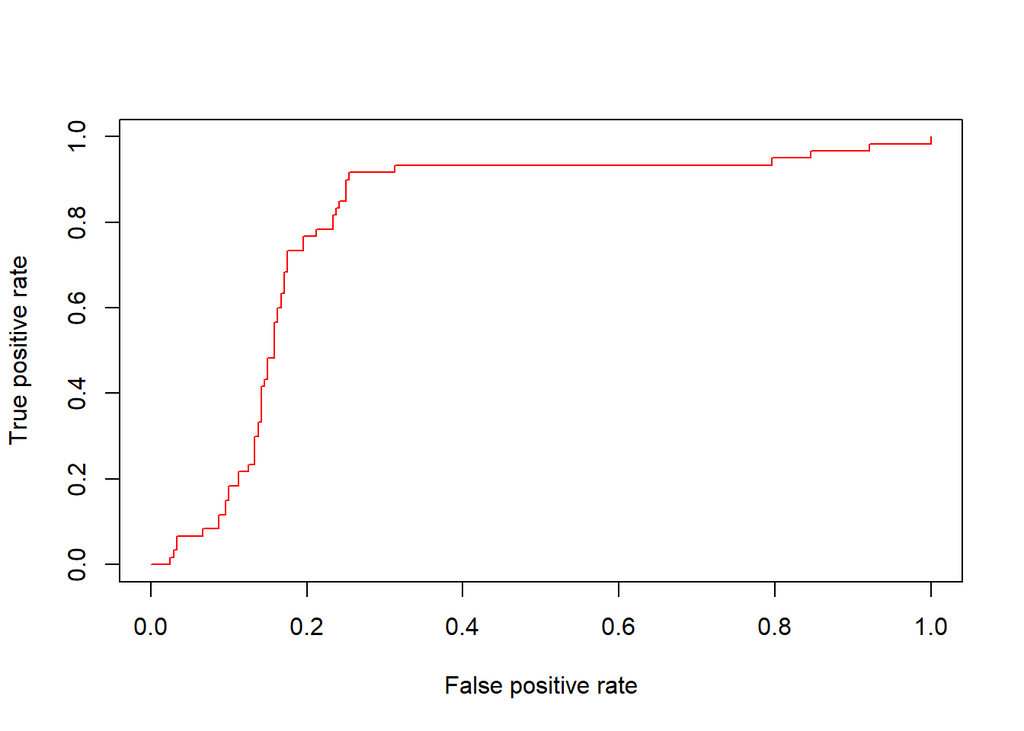

```r
data(ROCR.simple)

#All

pred <- prediction(glm.probs, Testing_set$Occupancy)

perf <- performance(pred, measure = "tpr", x.measure = "fpr")

plot(perf, col = "red")
```

```r
auroc <- performance(pred, measure = "auc")
auroc_value <- auroc@y.values[[1]]

auroc_value
```

```
## [1] 0.7977778
```

The Auroc value for glm.pred model is 0.7977778.

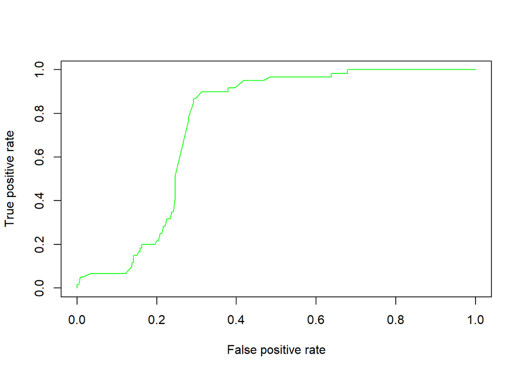

```r
#Temperature

pred <- prediction(glm.otemp.probs, Testing_set$Occupancy)

perf02 <- performance(pred, measure = "tpr", x.measure = "fpr")

plot(perf02, col = "green")
```

```r
auroc <- performance(pred, measure = "auc")
auroc_value <- auroc@y.values[[1]]

auroc_value
```

```
## [1] 0.7527431
```

The Auroc value for glm.otemp.pred model is 0.7527431.

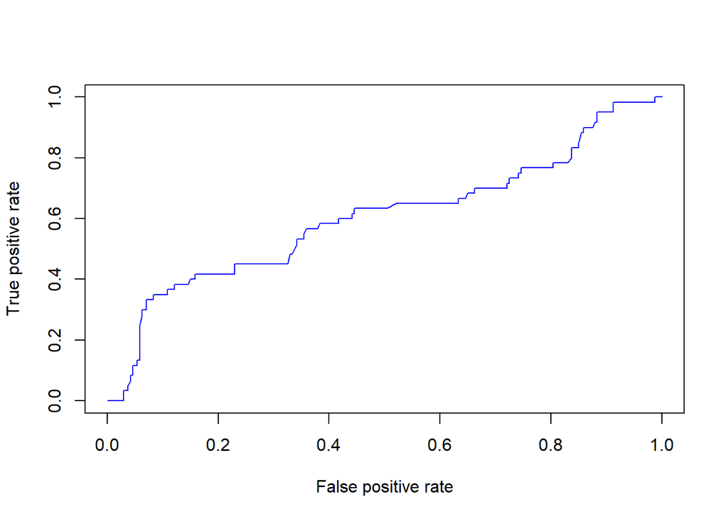

```r
#Humidity

pred <- prediction(glm.ohum.probs, Testing_set$Occupancy)

perf03 <- performance(pred, measure = "tpr", x.measure = "fpr")

plot(perf03, col = "Blue")
```

```r
auroc <- performance(pred, measure = "auc")
auroc_value <- auroc@y.values[[1]]

auroc_value
```

```
## [1] 0.6038194
```

The Auroc value for glm.ohum.pred model is 0.6038194.

The glm.pred model (which uses all the features) achieves the best accuracy amongst all three models. The Auroc value for the glm.pred model is the highest at 0.7977778, compared to the other two models, which are 0.6038194 when using only humidity as a predictor, and 0.7527431, when using only temperature as a predictor. In addition, the ROC curve for the glm.pred model (red curve) is the model with the closest curve to the upper left corner, which is the ideal point for a ROC curve. The other two curves, (green and blue) are further away from the upper left corner of the graph, indicating lower classification accuracy compared to the red curve.

# 6. Resampling Methods

Although both models will either underfit (model A) or overfit (model B) the data, I would consider model A as the better model. Model A is a quadratic model, therefore a curve will be produced for the training data which attempts to fit the cubic model. As a result, model A is a likely to fit the test data better, as model B will mostly likely overfit the data. Model B is more complex and flexible, this means the bias wil be lower, however the variance will be greater resulting most likely in overfitting. As a result, I would expect to get a more accurate prediction on the test data with model A, compared to model B.

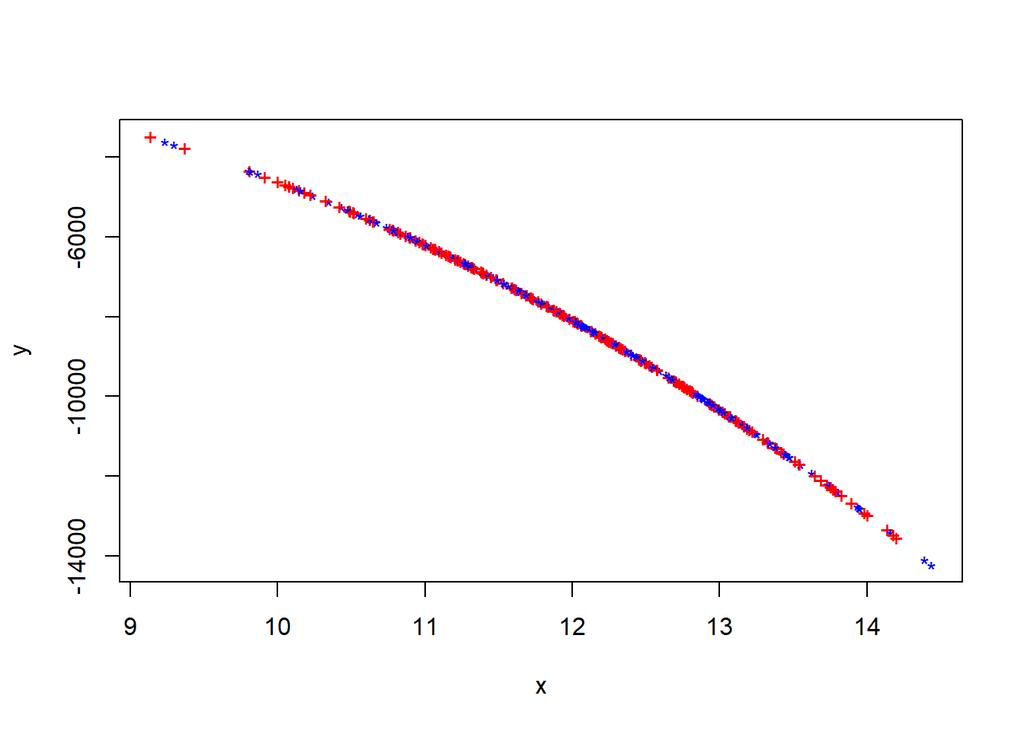

```r
set.seed(235)
x = 12 +rnorm(400)
y = 1 - x + 4*x^2 - 5*x^3 + rnorm(400)
plot(x,y, col=c("red","blue"), pch = c("+", "*"))
```

From the scatterplot, I can see that as x increases, y decreases. There is a strong negative correlation amongst the data.

```r
library(boot)
set.seed(34)
x = 12 +rnorm(400)
y = 1 - x + 4*x^2 - 5*x^3 + rnorm(400)

eq <- data.frame(x,y)

#first model

glm.fit8<- glm(y~poly(x,2), data=eq)

cv.err.1a<-cv.glm(eq,glm.fit8)

cv.err.1b<-cv.glm(eq,glm.fit8,K=10)

cv.err.1a$delta
```

```
## [1] 115.8783 115.8634
```

```r
cv.err.1b$delta
```

```
## [1] 113.0363 112.5722
```

The adjusted mean squared error rate (MSE) using the LOOCV method is 115.8634.

The adjusted mean squared error rate (MSE) using the 10 k-fold CV method is 112.5722.

```r
#second model

glm.fit2<- glm(y~poly(x,4), data=eq)

cv.err.2a<-cv.glm(eq,glm.fit2)

cv.err.2b<-cv.glm(eq,glm.fit2,K=10)

cv.err.2a$delta
```

```
## [1] 0.9520189 0.9519928
```

```r
cv.err.2b$delta
```

```
## [1] 0.9530072 0.9518483
```

The adjusted mean squared error rate (MSE) using the LOOCV method is 0.9519928.

The adjusted mean squared error rate (MSE) using the 10 k-fold CV method is 0.9518483.

```r
library(boot)
set.seed(68)
x = 12 +rnorm(400)
y = 1 - x + 4*x^2 - 5*x^3 + rnorm(400)

eq <- data.frame(x,y)

#first model

glm.fit3<- glm(y~poly(x,2), data=eq)

cv.err.3a<-cv.glm(eq,glm.fit3)

cv.err.3b<-cv.glm(eq,glm.fit3,K=10)

cv.err.3a$delta
```

```
## [1] 71.41475 71.40729
```

```r
cv.err.3b$delta
```

```
## [1] 72.98434 72.58147
```

The adjusted mean squared error rate (MSE) using the LOOCV method is 71.40729.

The adjusted mean squared error rate (MSE) using the 10 k-fold CV method is 72.58147.

```r
#second model

glm.fit4<- glm(y~poly(x,4), data=eq)

cv.err.4a<-cv.glm(eq,glm.fit4)

cv.err.4b<-cv.glm(eq,glm.fit4,K=10)

cv.err.4a$delta
```

```
## [1] 1.066981 1.066920
```

```r
cv.err.4b$delta
```

```
## [1] 1.078999 1.075833
```

The adjusted mean squared error rate (MSE) using the LOOCV method is 1.066920.

The adjusted mean squared error rate (MSE) using the 10 k-fold CV method is 1.075833.

The results when the seed is 34, and when it is 68 are not the same. This is because the set.seed function picks a different set of random numbers each time a new seed is set. Therefore, the results will never be the same when using different seeds to generate output, but results do remain repeatable if the same seed is used without change (i.e setting the seed to 34 and not changing it).

The second model which is a fourth degree polynomial has the smallest LOOCV and 10-fold CV error in question c. This is what I expected as I anticipated that this model would overfit the data, therefore seemingly producing a lower error rate. The first model, which is a second degree polynomial, has a very high error rate compared to the second model, and this is mostly likely because it is underfitting the data.

```r
summary(glm.fit8)
```

```
##
## Call:
## glm(formula = y ~ poly(x, 2), data = eq)
##
## Deviance Residuals:
##     Min       1Q   Median       3Q      Max
## -86.212   -6.113   -1.148    6.907   62.531
##
## Coefficients:
##               Estimate Std. Error  t value Pr(>|t|)
## (Intercept) -8.249e+03  5.128e-01 -16085.3   <2e-16 ***
## poly(x, 2)1 -4.189e+04  1.026e+01  -4083.8   <2e-16 ***
## poly(x, 2)2 -4.716e+03  1.026e+01   -459.8   <2e-16 ***
## ---
## Signif. codes:  0 '***' 0.001 '**' 0.01 '*' 0.05 '.' 0.1 ' ' 1
##
## (Dispersion parameter for gaussian family taken to be 105.2002)
##
##     Null deviance: 1776751608  on 399  degrees of freedom
## Residual deviance:      41764  on 397  degrees of freedom
## AIC: 3002.5
##
## Number of Fisher Scoring iterations: 2
```

```r
summary(glm.fit2)
```

```
##
## Call:
## glm(formula = y ~ poly(x, 4), data = eq)
##
## Deviance Residuals:
##     Min       1Q   Median       3Q      Max
## -3.5121  -0.6468  -0.0185   0.6312   2.8219
##
## Coefficients:
##               Estimate Std. Error    t value Pr(>|t|)
## (Intercept) -8.249e+03  4.857e-02 -1.698e+05   <2e-16 ***
## poly(x, 4)1 -4.189e+04  9.714e-01 -4.312e+04   <2e-16 ***
## poly(x, 4)2 -4.716e+03  9.714e-01 -4.855e+03   <2e-16 ***
## poly(x, 4)3 -2.034e+02  9.714e-01 -2.094e+02   <2e-16 ***
## poly(x, 4)4  2.117e+00  9.714e-01  2.179e+00   0.0299 *
## ---
## Signif. codes:  0 '***' 0.001 '**' 0.01 '*' 0.05 '.' 0.1 ' ' 1
##
## (Dispersion parameter for gaussian family taken to be 0.9436729)
##
##     Null deviance: 1.7768e+09  on 399  degrees of freedom
## Residual deviance: 3.7275e+02  on 395  degrees of freedom
## AIC: 1118.9
##
## Number of Fisher Scoring iterations: 2
```

Model A would have produced a model with low variance and high bias, indicating that it is an oversimplified model. This would signal that a more complex model should be used to fit the data. Nevertheless, for question (a), model A would have been the preferred model, as it would be less likely to overfit the data and somewhat provide more accurate results.

```r
library(boot)
set.seed(34)
x = 12 +rnorm(400)
y = 1 - x + 4*x^2 - 5*x^3 + rnorm(400)

eq <- data.frame(x,y)

#cubic model

glm.fit.cubic<- glm(y~poly(x,3), data=eq)

cv.err.cubica<-cv.glm(eq,glm.fit.cubic)

cv.err.cubicb<-cv.glm(eq,glm.fit.cubic,K=10)

cv.err.cubica$delta
```

```
## [1] 0.9650934 0.9650645
```

```r
cv.err.cubicb$delta
```

```
## [1] 0.9626199 0.9615719
```

```r
summary(glm.fit.cubic)
```

```
##
## Call:
## glm(formula = y ~ poly(x, 3), data = eq)
##
## Deviance Residuals:
##     Min       1Q   Median       3Q      Max
## -3.6206  -0.6596  -0.0093   0.6366   2.7828
##
## Coefficients:
##               Estimate Std. Error   t value Pr(>|t|)
## (Intercept) -8.249e+03  4.880e-02 -169036.5   <2e-16 ***
## poly(x, 3)1 -4.189e+04  9.760e-01  -42915.7   <2e-16 ***
## poly(x, 3)2 -4.716e+03  9.760e-01   -4832.2   <2e-16 ***
## poly(x, 3)3 -2.034e+02  9.760e-01    -208.4   <2e-16 ***
## ---
## Signif. codes:  0 '***' 0.001 '**' 0.01 '*' 0.05 '.' 0.1 ' ' 1
##
## (Dispersion parameter for gaussian family taken to be 0.9526055)
##
##     Null deviance: 1.7768e+09  on 399  degrees of freedom
## Residual deviance: 3.7723e+02  on 396  degrees of freedom
## AIC: 1121.7
##
## Number of Fisher Scoring iterations: 2
```

```r
summary(glm.fit8)
```

```
##
## Call:
## glm(formula = y ~ poly(x, 2), data = eq)
##
## Deviance Residuals:
##     Min       1Q   Median       3Q      Max
## -86.212   -6.113   -1.148    6.907   62.531
##
## Coefficients:
##               Estimate Std. Error  t value Pr(>|t|)
## (Intercept) -8.249e+03  5.128e-01 -16085.3   <2e-16 ***
## poly(x, 2)1 -4.189e+04  1.026e+01  -4083.8   <2e-16 ***
## poly(x, 2)2 -4.716e+03  1.026e+01   -459.8   <2e-16 ***
## ---
## Signif. codes:  0 '***' 0.001 '**' 0.01 '*' 0.05 '.' 0.1 ' ' 1
##
## (Dispersion parameter for gaussian family taken to be 105.2002)
##
##     Null deviance: 1776751608  on 399  degrees of freedom
## Residual deviance:      41764  on 397  degrees of freedom
## AIC: 3002.5
##
## Number of Fisher Scoring iterations: 2
```

The adjusted mean squared error rate (MSE) using the LOOCV method is 0.9650645.

The adjusted mean squared error rate (MSE) using the 10 k-fold CV method is 0.9615719.

The coefficient estimates and statistical significance of the coefficient estimates for poly(x, 3)1, poly(x, 3)2 and poly(x, 2)1, poly(x, 2)2 are the same for both model A and the cubic model. This suggests that we would have had a good result had we used Model A without knowing the function was cubic. Nevertheless, by including the third degree polynomial estimate in our model, we get a better result as this is what our actual data represents.

The LOOCV error for model A was 115.8634, and the LOOCV error for the cubic model is 0.9650645. The 10-fold CV error for model A was 112.5722, and the 10-fold CV error for the cubic model is 0.9615719. Overall, the LOOCV error and the 10-fold CV error was significantly lower for the cubic model, compared to model A which was quadratic. This is most likely due to the fact that model A is underfitting the data, and therefore does not output accurate predictions on the test data as the model has not learnt enough in the training stage on the training data.